# AlwaysR, Módulo III: Estadística en R.

Lab 03

Giancarlo M. Correa

En esta sección se resume los conceptos más importantes vistos en la parte práctica de cada clase.

Cargamos librerías a utilizar

```r
library(ggplot2)
library(Sleuth3)
library(faraway)
library(jtools)
library(ggstance)
library(broom.mixed)
```

Bases de datos a utilizar:

```r
head(cheddar)
```

```
##   taste Acetic   H2S Lactic
## 1  12.3  4.543 3.135   0.86
## 2  20.9  5.159 5.043   1.53
## 3  39.0  5.366 5.438   1.57
## 4  47.9  5.759 7.496   1.81
## 5   5.6  4.663 3.807   0.99
## 6  25.9  5.697 7.601   1.09
```

Si queremos saber que información contiene cada base de datos, podemos ver la ayuda de ellas mediante `?cheddar`.

## Modelos de regresión simple

Queremos evaluar cómo varía la media de la variable `taste` en función a la variable `H2S`. Implementamos el modelo lineal y observamos la tabla resumen:

```r
mod1 = lm(taste ~ H2S, data = cheddar)
summary(mod1)
```

```
##
## Call:
## lm(formula = taste ~ H2S, data = cheddar)
##
## Residuals:
##     Min      1Q  Median      3Q     Max
## -15.426  -7.611  -3.491   6.420  25.687
##
## Coefficients:
##             Estimate Std. Error t value Pr(>|t|)
## (Intercept)  -9.7868     5.9579  -1.643    0.112
## H2S           5.7761     0.9458   6.107 1.37e-06 ***
## ---
## Signif. codes:  0 '***' 0.001 '**' 0.01 '*' 0.05 '.' 0.1 ' ' 1
##
## Residual standard error: 10.83 on 28 degrees of freedom
## Multiple R-squared:  0.5712, Adjusted R-squared:  0.5558
## F-statistic: 37.29 on 1 and 28 DF,  p-value: 1.374e-06
```

Interpretación de la pendiente $\beta_1$: el valor medio de `taste` aumenta en 5.7761 cuando el valor de `H2S` aumenta en una unidad.

De esta tabla, podemos extraer información importante que puede ser reportada en nuestro estudio:

```r
mod1$coefficients # Coeficientes
```

```
## (Intercept)         H2S
##   -9.786837    5.776089
```

```r
mod1$residuals # Residuales
```

```
##          1          2          3          4          5          6          7
##   3.978800   1.558023  17.376468  14.389277  -6.602732  -8.217212  -3.315312
##          8          9         10         11         12         13         14
## -14.325484   5.648896   6.677444   9.210101  21.309529  -6.818324   7.141408
##         15         16         17         18         19         20         21
##  25.686687  -4.694300   3.090779 -10.960779  -7.874734  -3.667630  -4.799025
##         22         23         24         25         26         27         28
##  -5.164345 -11.595773   7.576510   5.423249   2.793608  -3.926291 -12.109221
##         29         30
## -15.426315 -12.363299
```

```r
mod1$fitted.values # Valores ajustados (sobre la linea ajustada) para las observaciones
```

```
##         1         2         3         4         5         6         7         8
##  8.321200 19.341977 21.623532 33.510723 12.202732 34.117212 40.615312 36.225484
##         9        10        11        12        13        14        15        16
## 12.451104 14.322556 25.689899 35.890471  7.518324 18.758592 29.213313 45.594300
##        17        18        19        20        21        22        23        24
## 12.809221 17.360779 25.874734 42.567630 18.799025 20.364345 43.595773 49.123490
##        25        26        27        28        29        30
## 11.376751  8.806392 30.426291 12.809221 28.826315 17.863299
```

También podemos extraer información de la tabla resumen:

```r
mySummary = summary(mod1)
mySummary$coefficients # coeficientes
```

```
##              Estimate Std. Error   t value     Pr(>|t|)
## (Intercept) -9.786837    5.95791 -1.642663 1.116377e-01
## H2S          5.776089    0.94585  6.106770 1.373783e-06
```

```r
mySummary$sigma # desviacion estandar de los residuales
```

```
## [1] 10.83338
```

```r
mySummary$adj.r.squared # R2-adj
```

```
## [1] 0.5558458
```

Si queremos encontrar los intervalos asociados a la línea ajustada:

```r
predict(object = mod1, interval = 'confidence')
```

```
##          fit        lwr      upr
## 1   8.321200  1.5397877 15.10261
## 2  19.341977 14.9320752 23.75188
## 3  21.623532 17.4560870 25.79098
## 4  33.510723 28.4626634 38.55878
## 5  12.202732  6.4129042 17.99256
## 6  34.117212 28.9452197 39.28920
## 7  40.615312 33.8688584 47.36177
## 8  36.225484 30.5866522 41.86432
## 9  12.451104  6.7204950 18.18171
## 10 14.322556  9.0173018 19.62781
## 11 25.689899 21.6198312 29.75997
## 12 35.890471 30.3292115 41.45173
## 13  7.518324  0.5190994 14.51755
## 14 18.758592 14.2678191 23.24937
```

[output cut: 16 more lines]

Si queremos encontrar los intervalos de predicción para los valores de $X$ observados:

```r
predict(object = mod1, interval = 'prediction')
```

```
##          fit         lwr      upr
## 1   8.321200 -14.8830218 31.52542
## 2  19.341977  -3.2831326 41.96709
## 3  21.623532  -0.9555722 44.20264
## 4  33.510723  10.7526194 56.26883
## 5  12.202732 -10.7313142 35.13678
## 6  34.117212  11.3312982 56.90313
## 7  40.615312  17.4212824 63.80934
## 8  36.225484  13.3290918 59.12188
## 9  12.451104 -10.4680639 35.37027
## 10 14.322556  -8.4939747 37.13909
## 11 25.689899   3.1285643 48.25123
## 12 35.890471  13.0130594 58.76788
## 13  7.518324 -15.7504858 30.78713
## 14 18.758592  -3.8824192 41.39960
```

[output cut: 16 more lines]

Este último intervalo lo vamos a guardar para poder graficarlo:

```r
newData_pred = predict(object = mod1, interval = 'prediction')
```

```r
plotData = cheddar
plotData = cbind(plotData, newData_pred)
```

Hacemos una gráfica sin los intervalos de predicción:

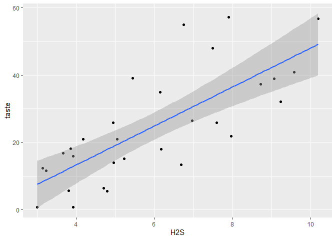

```r
ggplot(cheddar, aes(x = H2S, y = taste)) +
  geom_point() +
  geom_smooth(method='lm')
```

Ahora incluimos la línea de predicción:

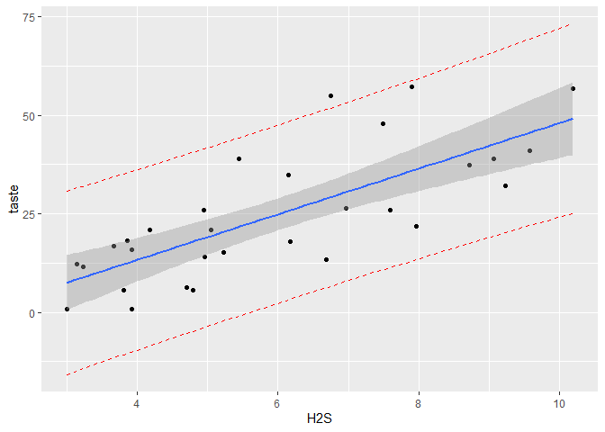

```r
ggplot(plotData, aes(x = H2S, y = taste )) +
  geom_point() +
  geom_smooth(method="lm", se=TRUE) +
  geom_line(aes(y=lwr), color = "red", linetype = "dashed") +
  geom_line(aes(y=upr), color = "red", linetype = "dashed")
```

Podemos predecir también para valores nuevos de $X$:

```r
newData = data.frame(H2S = seq(from = 2.8, to = 10.2, by = 0.1))
predict(object = mod1, newdata = newData, interval = 'prediction')
```

```
##          fit           lwr      upr
## 1   6.386211 -16.978644207 29.75107
## 2   6.963820 -16.351309398 30.27895
## 3   7.541428 -15.725481749 30.80834
## 4   8.119037 -15.101170651 31.33925
## 5   8.696646 -14.478385271 31.87168
## 6   9.274255 -13.857134550 32.40564
## 7   9.851864 -13.237427188 32.94115
## 8  10.429473 -12.619271644 33.47822
## 9  11.007082 -12.002676120 34.01684
## 10 11.584690 -11.387648560 34.55703
## 11 12.162299 -10.774196636 35.09880
## 12 12.739908 -10.162327748 35.64214
## 13 13.317517  -9.552049009 36.18708
## 14 13.895126  -8.943367243 36.73362
```

[output cut: 61 more lines]

> ADVERTENCIA: Si tenemos más de dos variables independientes ($X_1$ y $X_2$), y queremos hacer predicciones para nuevos valores de estas variables, tenemos que incluir cada combinación de estos nuevos valores. Utilizar la función `expand.grid` para hacer esto. Ver ejemplo [aquí](https://www.rdocumentation.org/packages/base/versions/3.6.2/topics/expand.grid).

Ahora podemos revisar los supuestos del modelo gráficamente:

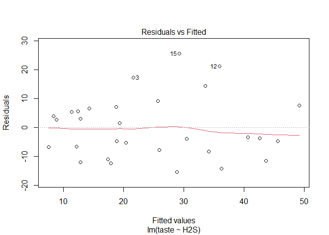

```r
plot(mod1, which = 1) # varianza constante
```

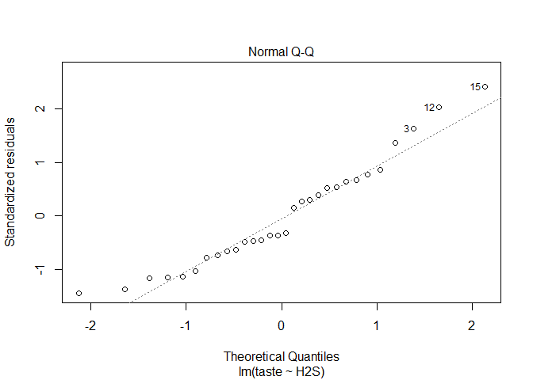

```r
plot(mod1, which = 2) # distribucion normal de residuos
```

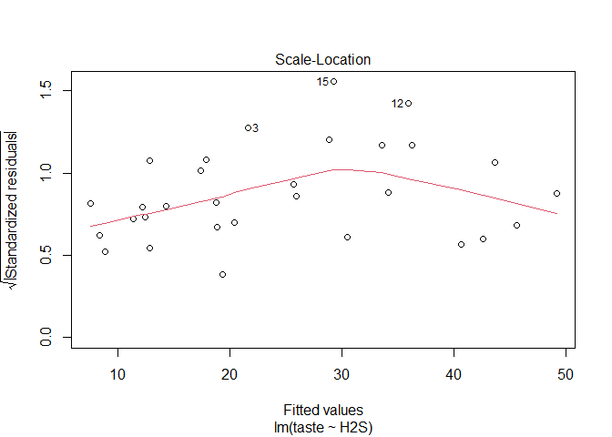

```r
plot(mod1, which = 3) # outliers
```

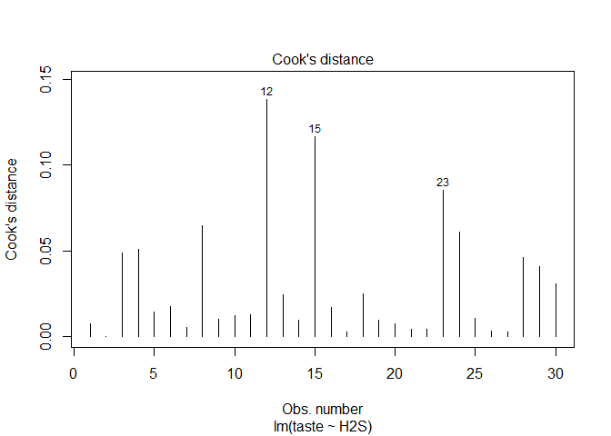

```r
plot(mod1, which = 4) # puntos influyentes
```

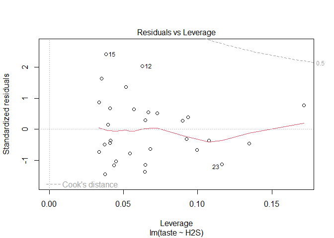

```r
plot(mod1, which = 5) # leverage
```

## Modelos de regresión múltiple

Podemos incluir una variable más al modelo anterior:

```r
mod2 = lm(taste ~ H2S + Lactic, data=cheddar)
summary(mod2)
```

```
##
## Call:
## lm(formula = taste ~ H2S + Lactic, data = cheddar)
##
## Residuals:
##     Min      1Q  Median      3Q     Max
## -17.343  -6.530  -1.164   4.844  25.618
##
## Coefficients:
##             Estimate Std. Error t value Pr(>|t|)
## (Intercept)  -27.592      8.982  -3.072  0.00481 **
## H2S            3.946      1.136   3.475  0.00174 **
## Lactic        19.887      7.959   2.499  0.01885 *
## ---
## Signif. codes:  0 '***' 0.001 '**' 0.01 '*' 0.05 '.' 0.1 ' ' 1
##
## Residual standard error: 9.942 on 27 degrees of freedom
## Multiple R-squared:  0.6517, Adjusted R-squared:  0.6259
## F-statistic: 25.26 on 2 and 27 DF,  p-value: 6.551e-07
```

Podemos hacer gráficas para observar los parámetros estimados y su error asociado:

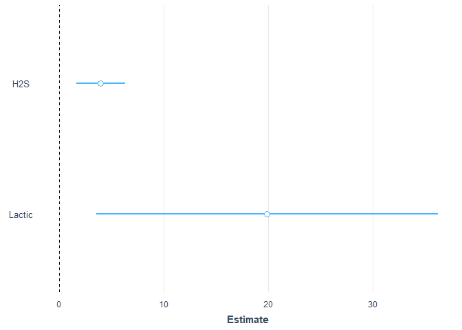

```r
plot_summs(mod2)
```

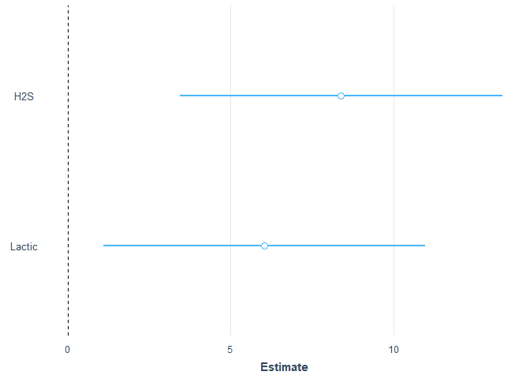

```r
plot_summs(mod2, scale = TRUE)
```

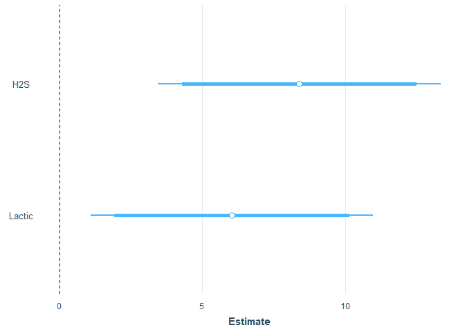

```r
plot_summs(mod2, scale = TRUE, inner_ci_level = .9)
```

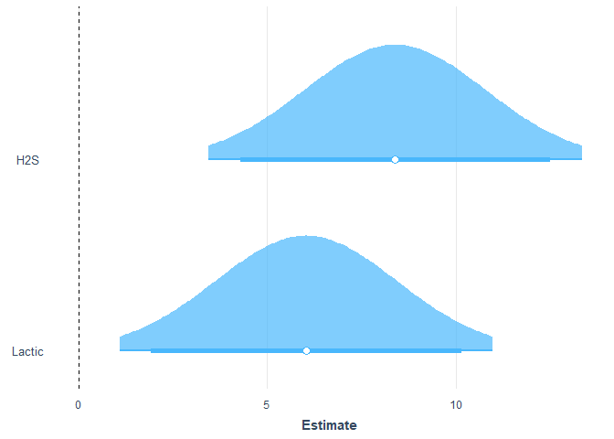

```r
plot_summs(mod2, scale = TRUE, plot.distributions = TRUE, inner_ci_level = .9)
```

También podemos comparar los estimados de dos modelos diferentes:

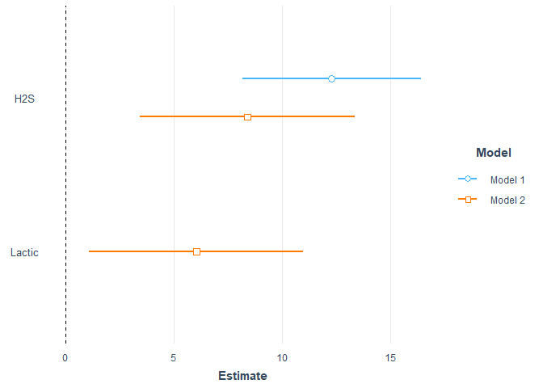

```r
plot_summs(mod1, mod2, scale = TRUE)
```

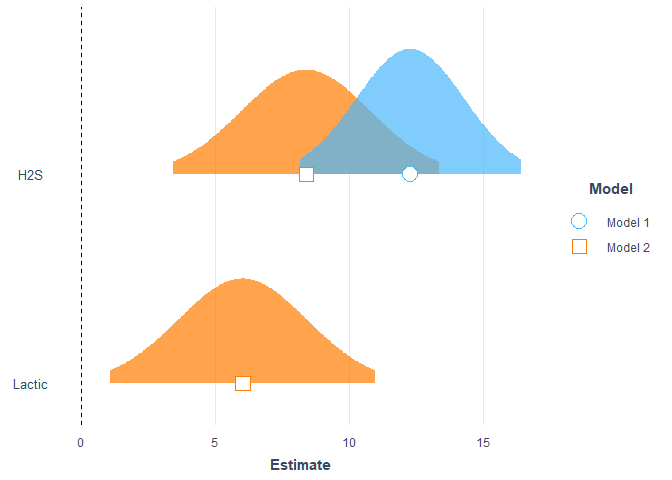

```r
plot_summs(mod1, mod2, scale = TRUE, plot.distributions = TRUE)
```